# Naive Bees Deep Learning with Images

## 1. Import Python libraries

[figure not shown]

*A honey bee (Apis).*

Can a machine identify a bee as a honey bee or a bumble bee? These bees have different [behaviors and appearances](https://www.thesca.org/connect/blog/bumblebees-vs-honeybees-what%E2%80%99s-difference-and-why-does-it-matter), but given the variety of backgrounds, positions, and image resolutions, it can be a challenge for machines to tell them apart.

Being able to identify bee species from images is a task that ultimately would allow researchers to more quickly and effectively collect field data. Pollinating bees have critical roles in both ecology and agriculture, and diseases like [colony collapse disorder](http://news.harvard.edu/gazette/story/2015/07/pesticide-found-in-70-percent-of-massachusetts-honey-samples/) threaten these species. Identifying different species of bees in the wild means that we can better understand the prevalence and growth of these important insects.

[figure not shown]

*A bumble bee (Bombus).*

### Instructions

Import the Python libraries with which you will work.

- Import `keras`, the deep learning library you'll be using.
- Import the function `Sequential` from the `models` module of `keras`. This is the model type you'll use.
- Import the functions `Dense`, `Dropout`, `Flatten`, `Conv2D`, `MaxPooling2D` from the `layers` module of `keras`. These will form the different layers of your convolutional neural network.

###### HINT

Here's a little help getting the import structure right! Try something like the following:

```
import keras
from keras.models import Sequential
from keras.layers import Dense, Dropout, Flatten, Conv2D, MaxPooling2D
```

```
BEGIN QUESTION
name: q1
points: 1
```

```python
import os

import pickle
from pathlib import Path
from skimage import io

from PIL import Image

import pandas as pd
import numpy as np

import matplotlib.pyplot as plt
%matplotlib inline

from sklearn.preprocessing import StandardScaler
from sklearn.model_selection import train_test_split
from sklearn.metrics import classification_report

# import accuracy_score from sklearn's metrics module
from sklearn.metrics import roc_curve, auc, accuracy_score

# import keras library
import keras

# import Sequential from the keras models module
from keras.models import Sequential

# import Dense, Dropout, Flatten, Conv2D, MaxPooling2D from the keras layers module
from keras.layers import Dense, Dropout, Flatten, Conv2D, MaxPooling2D
```

## 2. Load image labels

Now that we have all of our imports ready, it is time to look at the labels for our data. We will load our `labels.csv` file into a DataFrame called `labels`, where the index is the image name (e.g. an index of 1036 refers to an image named 1036.jpg) and the `genus` column tells us the bee type. `genus` takes the value of either `0.0` (Apis or honey bee) or `1.0` (Bombus or bumble bee).

### Instructions

Load the DataFrame of labels and image names, explore the dataset, then assign image labels to `y`.

- Using `read_csv` function from `pandas`, load the `labels.csv` file which lives in the `datasets` folder. Be sure to set `index_col=0` so that the images names are loaded as the index.
- Print the value counts of `genus` in the `labels` DataFrame. The dataset is imbalanced between the two classes.
- Assign the `genus` column values (the array of image labels) to `y`.

###### HINT

Recall `labels.csv` lives within the `datasets` folder, so it can be loaded with `labels = pd.read_csv('datasets/labels.csv', index_col=0)`. Remember to set `index_col=0` so that the image id is the index.

A numpy array of the values of a column be accessed from a pandas DataFrame with `.values` so `labels.genus.values` return the values of the `genus` column as an array.

```
BEGIN QUESTION
name: q2
points: 1
```

```python
# load labels.csv from datasets folder using pandas
labels = pd.read_csv('datasets/labels.csv', index_col=0)

# print value counts for genus
display(labels.genus.value_counts())

# assign the genus label values to y
y = labels.genus.values
```

```
1.0    3142
0.0     826
Name: genus, dtype: int64
```

###### Expected Output

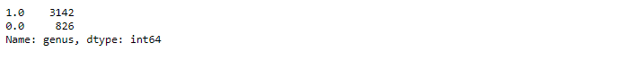

## 3. Examine RGB values in an image matrix

Image data can be represented as a matrix. The width of the matrix is the width of the image, the height of the matrix is the height of the image, and the depth of the matrix is the number of channels. Most image formats have three color channels: red, green, and blue.

For each pixel in an image, there is a value for every channel. The combination of the three values corresponds to the color, as per the [RGB color model](https://en.wikipedia.org/wiki/RGB_color_model). Values for each color can range from 0 to 255, so a purely blue pixel would show up as (0, 0, 255).

[figure not shown]

Let's explore the data for a sample image.

### Instructions

Load the first image from your DataFrame and explore its shape and RGB values.

###### HINT

Did you load your example image with `Image.open()`?

Remember that arrays can be sliced just like lists. The RGB channels for the top left pixel of the image can be accessed with `example_image[0, 0, :]`.

```
BEGIN QUESTION
name: q3
points: 1
```

```
Example image has shape:  (50, 50, 3)
RGB values for the top left pixel are: [126 108  94]
```

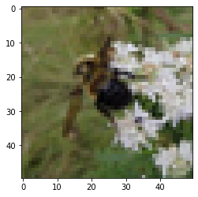

```python
# load an image and explore
example_image = Image.open('datasets/{}.jpg'.format(labels.index[0])).resize((50, 50), Image.ANTIALIAS)
example_image = np.array(example_image)

# show image
plt.imshow(example_image)

# print shape
print('Example image has shape: ', example_image.shape)

# print color channel values for top left pixel
print('RGB values for the top left pixel are:', example_image[0,0,:])
```

###### Expected Output

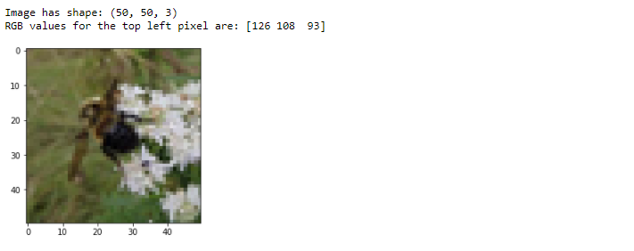

## 4. Normalize image data

Now we need to normalize our image data. Normalization is a general term that means changing the scale of our data so it is consistent.

In this case, we want each feature to have a similar range so our neural network can learn effectively across all the features. As explained in the [sklearn docs](http://scikit-learn.org/stable/modules/generated/sklearn.preprocessing.StandardScaler.html), "If a feature has a variance that is orders of magnitude larger than others, it might dominate the objective function and make the estimator unable to learn from other features correctly as expected."

We will scale our data so that it has a mean of 0 and standard deviation of 1. We'll use sklearn's `StandardScaler` to do the math for us, which entails taking each value, subtracting the mean, and then dividing by the standard deviation. We need to do this for each color channel (i.e. each feature) individually.

### Instructions

Normalize each feature (i.e. channel) of each image by iterating over the channels of each image in a for loop. Then stack the resulting arrays into a single matrix and assign it to X.

- Assign the `StandardScaler()` object to `ss`.
- Within the for loop that iterates over each channel of an image, call `ss.fit_transform` on each channel.
- Use `np.array()` to stack the `image_list` (a list of normalized image arrays) into an array that contains all of the images in the dataset.
- Print the shape of `X`.

###### HINT

Does your usage of `StandardScaler` look something like:

```
ss = StandardScaler()
img[:, :, channel] = ss.fit_transform(img[:, :, channel])
```

Did you remember to convert the list of image arrays into single array with `X = np.array(image_list)`?

```
BEGIN QUESTION
name: q4
points: 1
```

```python
# initialize standard scaler
ss = StandardScaler()

image_list = []
for i in labels.index:
    # load image
    img = Image.open('datasets/{}.jpg'.format(i)).resize((50, 50), Image.ANTIALIAS)
    img = np.array(img)

    # for each channel, apply standard scaler's fit_transform method
    for channel in range(img.shape[2]):
        img[:, :, channel] = ss.fit_transform(img[:, :, channel])

    # append to list of all images
    image_list.append(img)

# convert image list to single array
X = np.array(image_list)

# our dataset contains 3142 data points for class 1.0 and 826 data points for class 0.0.
# create balance class.
samples = ( np.random.default_rng( 24 ).choice( np.where(labels.genus.values == 0)[0], 826, replace=False).tolist()
            + np.random.default_rng( 48 ).choice(np.where(labels.genus.values == 1)[0], 826, replace=False).tolist() )

# X now contains 826 data points for class 1.0 and 826 data points for class 0.0
X, y = X[samples], y[samples]

# print shape of X
print(X.shape)
```

```
(1652, 50, 50, 3)
```

## 5. Split into train, test, and evaluation sets

Now that we have our big image data matrix, `X`, as well as our labels, `y`, we can split our data into train, test, and evaluation sets. To do this, we'll first allocate 20% of the data into our evaluation, or holdout, set. This is data that the model never sees during training and will be used to score our trained model.

We will then split the remaining data, 60/40, into train and test sets just like in supervised machine learning models. We will pass both the train and test sets into the neural network.

### Instructions

Split the data into train, test, and evaluation sets.

- Use `train_test_split` to split out 20% of the `X` and `y` data into validation sets by setting `test_size` equal to 0.2.
- Split the remaining data (`x_interim` and `y_interim`) into `x_train`, `x_test`, `y_train`, `y_test` so that 40% of the data goes into the test set. Be sure to set `random_state=52` to ensure consistent results.
- Print the shape of `x_train`.
- Print the number of samples in `x_train`.

###### HINT

Does your `train_test_split` code look something like this?

```
x_interim, x_eval, y_interim, y_eval = train_test_split(X, y, test_size=0.2, random_state=52)
x_train, x_test, y_train, y_test = train_test_split(x_interim, y_interim, test_size=0.4, random_state=52)
```

```
BEGIN QUESTION
name: q5
points: 1
```

```python
# split out evaluation sets (x_eval and y_eval)
x_interim, x_eval, y_interim, y_eval = train_test_split(X,
                                           y,
                                           test_size=0.2,
                                           random_state=52)

# split remaining data into train and test sets
x_train, x_test, y_train, y_test = train_test_split(x_interim,
                                                    y_interim,
                                                    test_size=0.4,
                                                    random_state=52)

# examine number of samples in train, test, and validation sets
print('x_train shape:', x_train.shape)
print(x_train.shape[0], 'train samples')
print(x_test.shape[0], 'test samples')
print(x_eval.shape[0], 'eval samples')
```

```
x_train shape: (792, 50, 50, 3)
792 train samples
529 test samples
331 eval samples
```

###### Expected Output

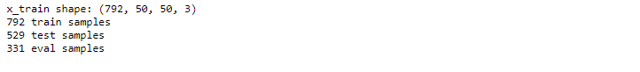

## 6. Model building (part i)

It's time to start building our deep learning model, a convolutional neural network (CNN). CNNs are a specific kind of artificial neural network that is very effective for image classification because they are able to take into account the spatial coherence of the image, i.e., that pixels close to each other are often related.

Building a CNN begins with specifying the model type. In our case, we'll use a [Sequential](https://keras.io/getting-started/sequential-model-guide/) model, which is a linear stack of layers. We'll then add two convolutional layers. To understand convolutional layers, imagine a flashlight being shown over the top left corner of the image and slowly sliding across all the areas of the image, moving across the image in the same way your eyes move across words on a page. Convolutional layers pass a kernel (a sliding window) over the image and perform element-wise matrix multiplication between the kernel values and the pixel values in the image.

### Instructions

Specify the number of classes in the model and then build the first two layers of the neural network.

- Set `num_classes` equal to `1`. Since your model is trying to predict whether an image is of a bumble bee or a honey bee (i.e. not a bumble bee), you can frame this as a binary classification problem.
- Define `model` as `Sequential()` to initialize the model.
- There is already one 2D convolutional layer in the code with 32 filters. Add another 2D convolutional layer (`Conv2D`), this time with 64 filters. It should have the same `kernel_size` and `activation` specifications as the first 2D convolutional layer.

The input shape in the first layer refers to the dimensions of the images that get passed in. The input shape does not need to specified after the first layer as the following layers can do automatic shape inference.

###### HINT

Remember that the convolutional layer you are adding looks a lot like the first one, except it has 64 filters instead of 32.

Your model so far should look something like:

```
model = Sequential()
model.add(Conv2D(32, kernel_size=(3, 3), activation='relu', input_shape=input_shape))
model.add(Conv2D(64, kernel_size=(3, 3), activation='relu')
```

```
BEGIN QUESTION
name: q6
points: 1
```

```python
# set model constants
num_classes = 1

# define model as Sequential
model = Sequential()

# first convolutional layer with 32 filters
model.add(Conv2D(32, kernel_size=(3, 3), activation='relu', input_shape=(50, 50, 3)))

# add a second 2D convolutional layer with 64 filters
model.add(Conv2D(64, kernel_size=(3, 3), activation='relu'))
```

## 7. Model building (part ii)

Let's continue building our model. So far our model has two convolutional layers. However, those are not the only layers that we need to perform our task. A complete neural network architecture will have a number of other layers that are designed to play a specific role in the overall functioning of the network. Much deep learning research is about how to structure these layers into coherent systems.

We'll add the following layers:

- [`MaxPooling`](https://keras.io/layers/pooling/#maxpooling2d). This passes a (2, 2) moving window over the image and downscales the image by outputting the maximum value within the window.
- [`Conv2D`](https://keras.io/layers/convolutional/#conv2d). This adds a third convolutional layer since deeper models, i.e. models with more convolutional layers, are better able to learn features from images.
- [`Dropout`](https://keras.io/layers/core/#dropout). This prevents the model from overfitting, i.e. perfectly remembering each image, by randomly setting 25% of the input units to 0 at each update during training.
- [`Flatten`](https://keras.io/layers/core/#flatten). As its name suggests, this flattens the output from the convolutional part of the CNN into a one-dimensional feature vector which can be passed into the following fully connected layers.
- [`Dense`](https://keras.io/layers/core/#dense). Fully connected layer where every input is connected to every output (see image below).
- [`Dropout`](https://keras.io/layers/core/#dropout). Another dropout layer to safeguard against overfitting, this time with a rate of 50%.
- `Dense`. Final layer which calculates the probability the image is either a bumble bee or honey bee.

To take a look at how it all stacks up, we'll print the model summary. Notice that our model has a whopping `3,669,249` paramaters. These are the different weights that the model learns through training and what are used to generate predictions on a new image.

[figure not shown]

### Instructions

Finish building the CNN and then print the model summary.

- Add a `MaxPooling2D` layer with `pool_size=(2, 2)`.
- Add a second `Dropout` layer with a rate of `0.5`.
- For the final `Dense` layer which generates predictions, pass in your previously specified `num_classes` as the first parameter. Set `sigmoid` as the activation function since this is a binary classification problem.
- Show the model summary using `model.summary()`.

Convolutional layers share weights across pixels, unlike fully connected layers.

###### HINT

Does your MaxPooling layer look like `model.add(MaxPooling2D(pool_size=(2, 2)))`?

Does your Dropout layer look like `model.add(Dropout(0.5))`?

Does your Dense predictions layer look like `model.add(Dense(num_classes, activation='sigmoid', name='preds'))`?

```
BEGIN QUESTION
name: q7
points: 1
```

```python
# reduce dimensionality through max pooling
model.add(MaxPooling2D(pool_size=(2, 2)))

# third convolutional layer with 64 filters
model.add(Conv2D(64, kernel_size=(3, 3), activation='relu'))
# add dropout to prevent over fitting
model.add(Dropout(0.25))
# necessary flatten step preceeding dense layer
model.add(Flatten())
# fully connected layer
model.add(Dense(128, activation='relu'))

# add additional dropout to prevent overfitting
model.add(Dropout(0.50))

# prediction layers
model.add(Dense(num_classes, activation='sigmoid', name='preds'))

# show model summary
model.summary()
```

```
Model: "sequential"
_________________________________________________________________
Layer (type)                 Output Shape              Param #
=================================================================
conv2d (Conv2D)              (None, 48, 48, 32)        896
_________________________________________________________________
conv2d_1 (Conv2D)            (None, 46, 46, 64)        18496
_________________________________________________________________
max_pooling2d (MaxPooling2D) (None, 23, 23, 64)        0
_________________________________________________________________
conv2d_2 (Conv2D)            (None, 21, 21, 64)        36928
_________________________________________________________________
dropout (Dropout)            (None, 21, 21, 64)        0
_________________________________________________________________
flatten (Flatten)            (None, 28224)             0
_________________________________________________________________
dense (Dense)                (None, 128)               3612800
_________________________________________________________________
dropout_1 (Dropout)          (None, 128)               0
_________________________________________________________________
preds (Dense)                (None, 1)                 129
=================================================================
Total params: 3,669,249
Trainable params: 3,669,249
Non-trainable params: 0
_________________________________________________________________
```

###### Expected Output

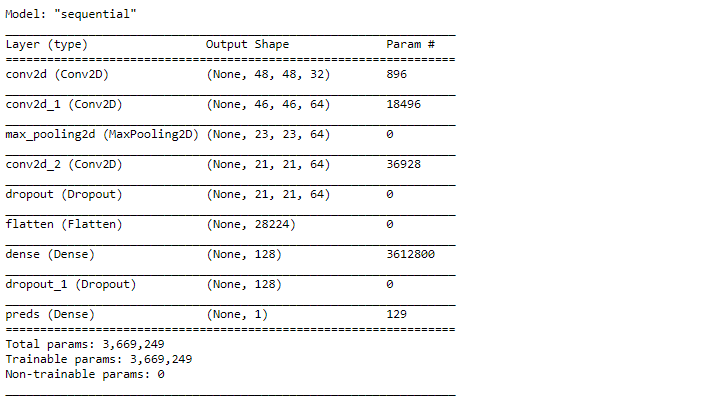

## 8. Compile and train model

Now that we've specified the model architecture, we will compile the model for training. For this we need to specify the loss function (what we're trying to minimize), the optimizer (how we want to go about minimizing the loss), and the metric (how we'll judge the performance of the model).

Then, we'll call [`.fit`](https://keras.io/models/model/#fit) to begin the trainig the process.

> "Neural networks are trained iteratively using optimization techniques like gradient descent. After each cycle of training, an error metric is calculated based on the difference between prediction and target…Each neuron’s coefficients (weights) are then adjusted relative to how much they contributed to the total error. This process is repeated iteratively." [ML Cheatsheet](https://ml-cheatsheet.readthedocs.io/en/latest/nn_concepts.html)

### Instructions

- In the compile function, set `keras.losses.binary_crossentropy` as the loss and set `accuracy` as the metric.
- In the fit function which trains the model, set epochs equal to `200`.

###### HINT

Does your code look something like:

```
model.compile(
    loss=keras.losses.binary_crossentropy,
    optimizer=keras.optimizers.SGD(lr=0.001),
    metrics=['accuracy']
)
```

```
BEGIN QUESTION
name: q8
points: 1
```

```python
model.compile(
    # set the loss as binary_crossentropy
    loss=keras.losses.binary_crossentropy,
    # set the optimizer as stochastic gradient descent
    optimizer=keras.optimizers.SGD(lr=0.001),
    # set the metric as accuracy
    metrics=['accuracy']
)

# mock-train the model using the first ten observations of the train and test sets
history = model.fit(
    x_train[0:, :, :, :],
    y_train[:],
    epochs=200,
    verbose=1,
    validation_data=(x_test[0:, :, :, :], y_test[:])
)
```

###### Expected Output

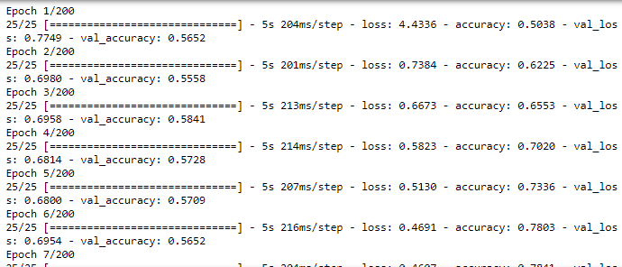

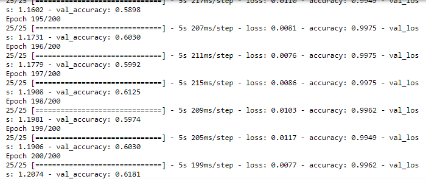

Let's use the [`evaluate`](https://keras.io/models/model/#evaluate) method to see how well the model did at classifying bumble bees and honey bees for the test and validation sets. Recall that accuracy is the number of correct predictions divided by the total number of predictions. Given that our classes are balanced, a model that predicts `1.0` for every image would get an accuracy around `0.5`.

### Instructions

Calculate the loss and accuracy for the holdout set.

- Evaluate the pretrained model on the holdout set (`x_eval` and `y_eval`) using the `.evaluate` method.
- Assign the resulting tuple to `eval_score`.
- Print the loss for the holdout set.
- Print the accuracy for the holdout set.

###### HINT

Regarding the evaluation on the holdout set, remember that:

- the holdout set refers to `x_eval` and `y_eval`.
- `.evaluate()` returns a tuple object where the first item is loss and the second is accuracy.

```
BEGIN QUESTION
name: q9
points: 1
```

```python
# evaluate model on test set
score = model.evaluate(x_test, y_test, verbose=0)
print('Test loss:', score[0])
print('Test accuracy:', score[1])

print("")

# evaluate model on holdout set
eval_score = model.evaluate(x_eval, y_eval, verbose=0)
# print loss score
print('Eval loss:', eval_score[0])
# print accuracy score
print('Eval accuracy:', eval_score[1])
```

```
Test loss: 1.153319001197815
Test accuracy: 0.6238185167312622

Eval loss: 1.0154304504394531
Eval accuracy: 0.652567982673645
```

###### Expected Output

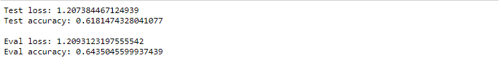

## 10. Visualize model training history

### Instructions

Load the model history and plot the validation accuracy and loss over the training period.

###### HINT

Does your plotting code look something like:

```
plt.plot(history.history['accuracy'])
plt.plot(history.history['val_accuracy'])
```

```
BEGIN QUESTION
name: q10
points: 1
```

```
dict_keys(['loss', 'accuracy', 'val_loss', 'val_accuracy'])
```

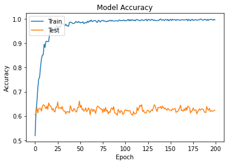

```python
# print keys for history.history dict
print(history.history.keys())

# summarize history for accuracy
plt.plot(history.history['accuracy']) # train accuray
plt.plot(history.history['val_accuracy']) # validation accuracy
plt.title('Model Accuracy')
plt.ylabel('Accuracy')
plt.xlabel('Epoch')
plt.legend(['Train', 'Test'], loc='upper left')
plt.show()
```

###### Expected Output

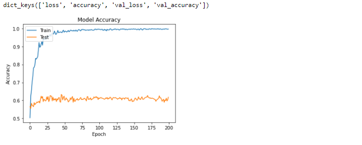

## 11. Generate predictions

Previously, we calculated an overall score for our pre-trained model on the validation set. To end this notebook, let's access probabilities and class predictions for individual images using the `.predict()` method and `np.round()`.

We now have a deep learning model that can be used to identify honey bees and bumble bees in images! The next step is to explore transfer learning, which harnesses the prediction power of models that have been trained on far more images than the mere 1600 in our dataset.

### Instructions

Finally, you'll get the predicted probabilities and classes for each image in the validation set.

- Use the `.predict()` method from our trained `model` to get the probabilities for `x_eval` and assign them to `y_proba`.
- Print the first five probabilities in the `y_proba` list you just created.
- Use `np.round()` and `.astype('int')` on `y_proba` to get the predicted classes and assign them to `y_pred`. Note that those with a probability greater than 0.5 were assigned class 1, a bumble bee.
- Calculate the `AUC` from `false_positive_rate` and `true_positive_rate` and assign it to `roc_auc`.
- Plot the false positive rate on the x axis and the true positive rate on the y axis to show the `ROC` curve.

###### HINT

Does your code look something like:

```
y_proba = pretrained_cnn.predict(x_eval)
y_pred = np.round(y_proba).astype('int')
```

Remember that the first five items in a list can be accessed with slicing. Accessing the first three elements would look like `y_proba[:3]`.

```
BEGIN QUESTION
name: q11
points: 1
```

```
First five probabilities:
[[0.23919353]
 [0.04084057]
 [0.23237365]
 [0.13173798]
 [0.9686369 ]]

First five class predictions:
[[0]
 [0]
 [0]
 [0]
 [1]]
```

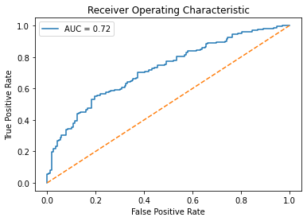

```python
# predicted probabilities for x_eval
y_proba = model.predict(x_eval)

print("First five probabilities:")
print(y_proba[:5])
print("")

# predicted classes for x_eval
y_pred = np.round(y_proba).astype('int')

print("First five class predictions:")
print(y_pred[:5])
print("")


# calculate false positive rate and true positive rate at different thresholds
false_positive_rate, true_positive_rate, thresholds = roc_curve(y_eval, y_proba, pos_label=1)

# calculate AUC
roc_auc = auc(false_positive_rate, true_positive_rate)

plt.title('Receiver Operating Characteristic')
# plot the false positive rate on the x axis and the true positive rate on the y axis
roc_plot = plt.plot(false_positive_rate,
                    true_positive_rate,
                    label='AUC = {:0.2f}'.format(roc_auc))

plt.legend(loc=0)
plt.plot([0,1], [0,1], ls='--')
plt.ylabel('True Positive Rate')
plt.xlabel('False Positive Rate');
```

###### Expected Output

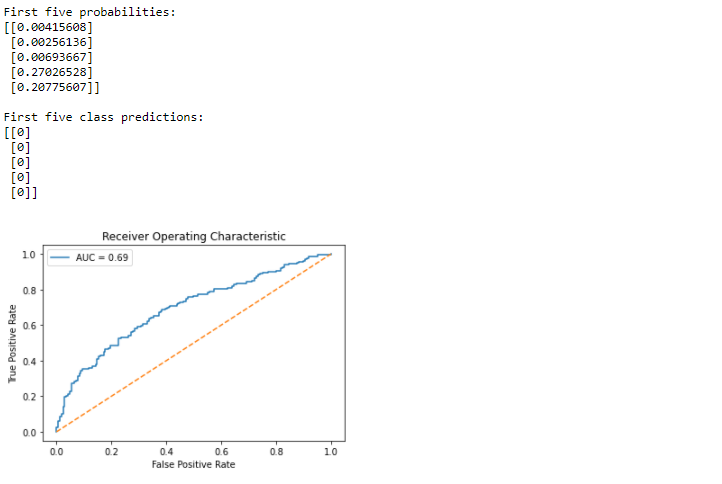